# Analysis of Car Sales and Economic Trends

Tommy Tight

2024-05-06

#### QUESTION 2 - For the variable “Gold” (column R in the data file), subset the data to include the 2nd and 3rd quartile. Select the most appropriate chart/graph/plot type and create a well-formatted plot of your subset data.

```r
#read in and subset data
premium_data <- read_csv("~/Library/CloudStorage/GoogleDrive-ttight@nd.edu/My Drive/Past Semesters/Spring Semester - Sophomore Year /Predictive Analytics/Final Exam Prep/A0 Premium.csv")
premium_data <- premium_data[1:162, ]

#Check for missing values
summary(premium_data)
```

```
##      Date             A0 Premium         CPI              Oil
##  Length:162         Min.   :  8.0   Min.   : 2.200   Min.   : 30.70
##  Class :character   1st Qu.: 54.0   1st Qu.: 6.450   1st Qu.: 55.95
##  Mode  :character   Median :126.0   Median : 8.110   Median : 72.31
##                     Mean   :152.1   Mean   : 8.859   Mean   : 77.48
##                     3rd Qu.:204.8   3rd Qu.:11.822   3rd Qu.:106.01
##                     Max.   :514.0   Max.   :16.930   Max.   :132.72
##
##       USD             CCI              BCI           Prime rate
##  Min.   :23.35   Min.   : 93.26   Min.   : 96.13   Min.   : 5.500
##  1st Qu.:25.36   1st Qu.: 98.84   1st Qu.: 99.90   1st Qu.: 8.062
##  Median :31.02   Median :101.02   Median :100.30   Median :10.000
##  Mean   :37.74   Mean   :100.10   Mean   :100.07   Mean   : 9.818
##  3rd Qu.:54.25   3rd Qu.:101.75   3rd Qu.:100.55   3rd Qu.:11.000
##  Max.   :77.29   Max.   :103.64   Max.   :101.41   Max.   :17.000
##
##     Imports         Exports          Unemp         Gold Reserves
##  Min.   : 9354   Min.   :16565   Min.   :0.04700   Min.   : 3727
##  1st Qu.:15584   1st Qu.:25523   1st Qu.:0.05400   1st Qu.:13141
##  Median :19684   Median :31542   Median :0.05800   Median :40835
##  Mean   :20201   Mean   :32681   Mean   :0.06251   Mean   :35240
##  3rd Qu.:26328   3rd Qu.:41696   3rd Qu.:0.07075   3rd Qu.:48879
##  Max.   :29862   Max.   :48014   Max.   :0.09200   Max.   :81146
##
##  Total Reserves      Gasoline      Natural Gas        Propane
##  Min.   :124541   Min.   :0.960   Min.   : 1.700   Min.   :0.3400
##  1st Qu.:372721   1st Qu.:1.600   1st Qu.: 2.960   1st Qu.:0.7600
##  Median :430113   Median :2.000   Median : 3.970   Median :0.9600
##  Mean   :412735   Mean   :2.106   Mean   : 4.785   Mean   :0.9791
##  3rd Qu.:498857   3rd Qu.:2.720   3rd Qu.: 6.200   3rd Qu.:1.1800
##  Max.   :596566   Max.   :3.290   Max.   :13.520   Max.   :1.8600
##                   NA's   :1       NA's   :1        NA's   :1
##      Silver           Gold           Aluminum    Industrial productivity
##  Min.   : 6.62   Min.   : 421.9   Min.   :1330   Min.   : 88.66
##  1st Qu.:13.67   1st Qu.: 839.0   1st Qu.:1804   1st Qu.: 99.51
##  Median :16.95   Median :1200.6   Median :1990   Median :107.14
##  Mean   :18.50   Mean   :1114.3   Mean   :2073   Mean   :106.02
##  3rd Qu.:20.55   3rd Qu.:1330.7   3rd Qu.:2378   3rd Qu.:112.39
##  Max.   :42.70   Max.   :1772.1   Max.   :3071   Max.   :121.10
##  NA's   :1       NA's   :1        NA's   :1
##  Capital Utilization Efficiency (1=efficient)
##  Min.   :0.0000
##  1st Qu.:1.0000
##  Median :1.0000
##  Mean   :0.7593
##  3rd Qu.:1.0000
##  Max.   :1.0000
##
##  Finished Goods (1=efficient, 0 - not)
##  Min.   :0.000
##  1st Qu.:0.000
##  Median :0.000
##  Mean   :0.463
##  3rd Qu.:1.000
##  Max.   :1.000
##
```

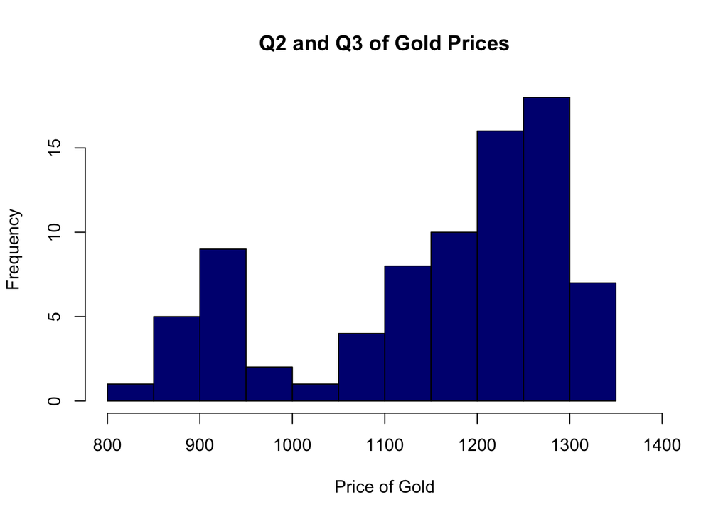

```r
#The variables gasoline through aluminium each have one missing value, so I
#will remove the missing values from the dataset
premium_data <- na.omit(premium_data)


#Subsetting data to include the second and third quartile of Gold variable

q_2 <- quantile(premium_data$Gold, 0.25)
q_3 <- quantile(premium_data$Gold, 0.75)


gold_q2_q3 <- premium_data$Gold[premium_data$Gold >= q_2 & premium_data$Gold <= q_3]

hist(gold_q2_q3, col = "navy", main = "Q2 and Q3 of Gold Prices", xlab = "Price of Gold", xlim = c(800, 1400))
```

#### QUESTION 3 - 1.) Examine your car sales variable in column B Create a well-formatted plot of your data. What could be possible time-series components present in your data? (Do not detrend - this is not necessary. I am asking you to evaluate the presence of time-series components based on what you know and see.) 2.) Examine your car sales variable against all variables in the dataset. Provide three variables with strongest relationship with your car sales. 3.) Write a brief explanation how these three variables could affect your car sales variable (no calculations are necessary).

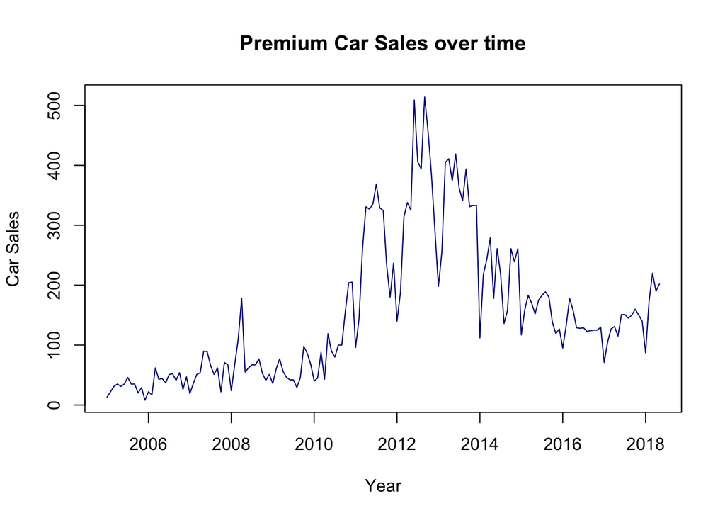

```r
#Make data time-series. Only goes to May of 2018 due to removal of row 162.
premium_ts <- ts(premium_data$`A0 Premium`, frequency = 12,
                 start = c(2005, 1),
                 end = c(2018, 5))

#Plot time-series premium data
plot(premium_ts,
     main = "Premium Car Sales over time",
     col = "navy",
     xlab = "Year",
     ylab = "Car Sales")
```

```r
#Check correlation of car sales against all other variables in the dataset.
#Removing column 1, as the date will not have correlation with car sales.
premium_matrix <- as.matrix(premium_data[ , -1])
cor(premium_matrix)
```

```
##                                               A0 Premium         CPI
## A0 Premium                                    1.00000000 -0.38268033
## CPI                                          -0.38268033  1.00000000
## Oil                                           0.58828366 -0.19938872
## USD                                           0.09151538 -0.18594938
## CCI                                           0.12594664 -0.32364195
## BCI                                           0.10359147 -0.43761654
## Prime rate                                   -0.55226359  0.71502096
## Imports                                       0.74831460 -0.41100656
## Exports                                       0.69598188 -0.31844730
## Unemp                                        -0.52725346  0.37261146
## Gold Reserves                                 0.54932612 -0.59063470
## Total Reserves                                0.59905678 -0.32253044
## Gasoline                                      0.62603796 -0.22669942
## Natural Gas                                  -0.47977799  0.41600927
## Propane                                       0.04582983 -0.04192130
## Silver                                        0.75588166 -0.40001046
## Gold                                          0.78111455 -0.52740691
## Aluminum                                     -0.16670321 -0.01060143
## Industrial productivity                       0.47183349 -0.46404300
## Capital Utilization Efficiency (1=efficient)  0.36891887 -0.60707739
## Finished Goods (1=efficient, 0 - not)        -0.09780887  0.10115007
##                                                      Oil         USD
## A0 Premium                                    0.58828366  0.09151538
## CPI                                          -0.19938872 -0.18594938
## Oil                                           1.00000000 -0.51438923
## USD                                          -0.51438923  1.00000000
## CCI                                           0.58358203 -0.60477238
## BCI                                           0.09901739  0.17602614
## Prime rate                                   -0.62046554  0.07286196
## Imports                                       0.85066814 -0.14515724
## Exports                                       0.91489510 -0.22685524
## Unemp                                        -0.22871228 -0.50634177
## Gold Reserves                                 0.03322689  0.76570858
## Total Reserves                                0.68130070  0.01091179
## Gasoline                                      0.97982283 -0.46077908
## Natural Gas                                   0.08119785 -0.61066473
## Propane                                       0.74463362 -0.70825540
## Silver                                        0.70681666 -0.05684845
## Gold                                          0.50464253  0.32207619
```

[output cut: 209 more lines]

```
## Prime rate                                                            0.0976439872
## Imports                                                              -0.0893806243
## Exports                                                              -0.0752633921
## Unemp                                                                 0.3612301515
## Gold Reserves                                                        -0.2809723151
## Total Reserves                                                       -0.1202231807
## Gasoline                                                              0.0003657618
## Natural Gas                                                           0.2121195848
## Propane                                                               0.0684532238
## Silver                                                               -0.1939168170
## Gold                                                                 -0.2149117196
## Aluminum                                                             -0.1378101630
## Industrial productivity                                              -0.3748102033
## Capital Utilization Efficiency (1=efficient)                         -0.2726450322
## Finished Goods (1=efficient, 0 - not)                                 1.0000000000
```

1.) One time-series trend that I think could be a part of the data is a cycle that starts around 2009. Here, the data seems to change from being linear to being quadratic, before returning to what appears to be a more linear trend again, which is indicative of a cycle. Additionally, there appears to be a linear trend, as the data overall seems to increase linearly. My guess is that after I remove the cycle, the linear trend will become much more visible. There are likely other trends, including power trends and seasonality in the data, but they are not very visible at this point. There is also always random noise and signal in time-series data.

2.) Car sales (A0.Premium) has the strongest correlation with: Gold (0.78111455), Silver (0.75588166), and Imports (0.74831460) in that order.

3.) All three of these variables have strong, positive linear relationships with A0.Premium. This means that, as these variables increase, car sales for this type of car will also tend to increase. Increases in the value of gold and silver, as well as increasing imports could be indicative of poor economic performace, which could lead to only wealthy people, who are buying premium cars, being able to buy cars. This could mean increases in premium car sales.